# R Notebook

# Green spaces

```r
green_spaces
```

| feature_code | date_code | measurement | units | value | distance_to_nearest_green_or_blue_space | age | gender | urban_rural_classification | simd_quintiles | type_of_tenure | household_type | ethnicity |
| --- | --- | --- | --- | --- | --- | --- | --- | --- | --- | --- | --- | --- |
| S12000026 | 2013 | 95% Lower Confidence Limit, Percent | Percent Of Adults | 71.0 | A 5 minute walk or less | All | All | All | All | All | All | All |
| S12000045 | 2017 | Percent | Percent Of Adults | 59.0 | A 5 minute walk or less | All | All | All | All | All | Pensioners | All |
| S12000026 | 2014 | 95% Upper Confidence Limit, Percent | Percent Of Adults | 86.9 | A 5 minute walk or less | All | All | All | All | All | All | All |
| S12000026 | 2017 | 95% Upper Confidence Limit, Percent | Percent Of Adults | 80.9 | A 5 minute walk or less | All | All | All | All | All | All | All |
| S12000026 | 2017 | 95% Upper Confidence Limit, Percent | Percent Of Adults | 79.6 | A 5 minute walk or less | All | All | All | All | All | Pensioners | All |
| S12000026 | 2014 | 95% Lower Confidence Limit, Percent | Percent Of Adults | 76.8 | A 5 minute walk or less | All | All | All | All | All | All | All |
| S12000026 | 2013 | 95% Upper Confidence Limit, Percent | Percent Of Adults | 80.7 | A 5 minute walk or less | All | All | All | All | All | Pensioners | All |
| S12000026 | 2014 | Percent | Percent Of Adults | 77.0 | A 5 minute walk or less | All | Female | All | All | All | All | All |
| S12000033 | 2017 | 95% Lower Confidence Limit, Percent | Percent Of Adults | 53.0 | A 5 minute walk or less | All | Male | All | All | All | All | All |
| S12000026 | 2014 | 95% Lower Confidence Limit, Percent | Percent Of Adults | 80.0 | A 5 minute walk or less | All | Male | All | All | All | All | All |

[output cut: 990 more lines]

```r
green_spaces %>%
  distinct(age)
```

| age |
| --- |
| All |
| 16-34 years |
| 65 years and over |
| 35-64 years |

- feature_code = council area or all of scotland
- date_code = year between 2013 and 2019
- measurement = whether the value is a percent, or confidence limit
- value = percent of people that gave that rating or upper and lower confidence levels for that percentage
- **distance_to_nearest_green_or_blue_space** = 5 minute walk or less / 6-10 minute walk / 11+ minute walk / Don’t know
- age = 16-34 / 35-64 / 65+
- gender = Male/Female
- urban_rural_classification = Urban/Rural
- simd_quintiles = 80% least deprived/20% most deprived
- type_of_tenure = Owned Mortgage/Loan / Owned Outright / Social Rented / Private Rented / Other
- household_type = With Children / Pensioners / Adults
- ethnicity = White / Other

This dataset tells us who has access to green or blue spaces within 10 minutes.

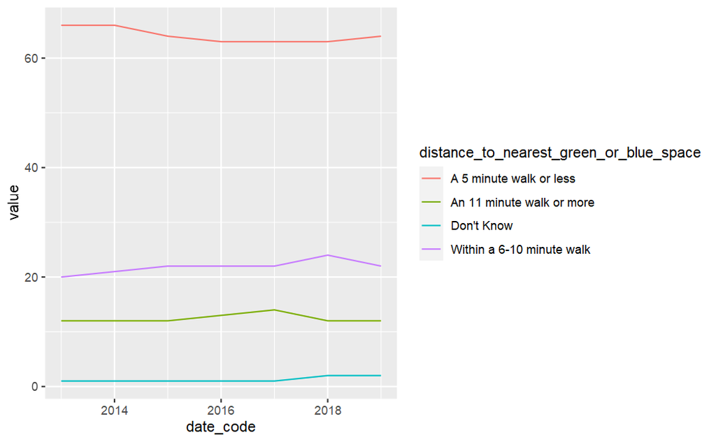

```r
green_spaces %>%
  left_join(council_areas_clean, by = c("feature_code" = "ca")) %>%
  filter(ca_name == "Scotland",
         urban_rural_classification == "Urban",
         measurement == "Percent") %>%
  ggplot(aes(date_code, value, colour = distance_to_nearest_green_or_blue_space)) +
  geom_line()
```

[output not shown]